# Lizard Lengths Report

Sachi Shiroma

11/29/2021

# Introduction

This data shows the various lengths in millimeters of lizard species by sex. We will determine whether or not there a significant difference in total length difference in mean total length between female lizards belonging to two different types of species (Colorado Checkered and Desert Grassland). The methods being used will be from the calculations of the mean lengths of female lizards by species, as well as the standard deviation and the population counts. The Cohen’s d effect size will also be calculated from the mean values of the two different species of female lizards and will be used to determine if there is a siginificant difference.

```r
# Read in the data
lizard_data <- read_csv(here("data", "lizards.csv"))
```

```r
# Create a subset with these columns: species, sex and lizard lengths
lizards_subset <- lizard_data %>%
select(spp, sex, total_length)
```

```r
# Create a subset with just female lizards
lizards_sex_species <- lizards_subset %>%
 filter(sex == "F") %>%
# Filter species for Colorado and Desert lizards
 filter(spp %in% c("CNUN", "CNTE")) %>%
# Change species to full names
 mutate(spp = case_when(
   spp == "CNTE" ~ "Colorado Checkered",
   spp == "CNUN" ~ "Desert Grassland"
 ))
```

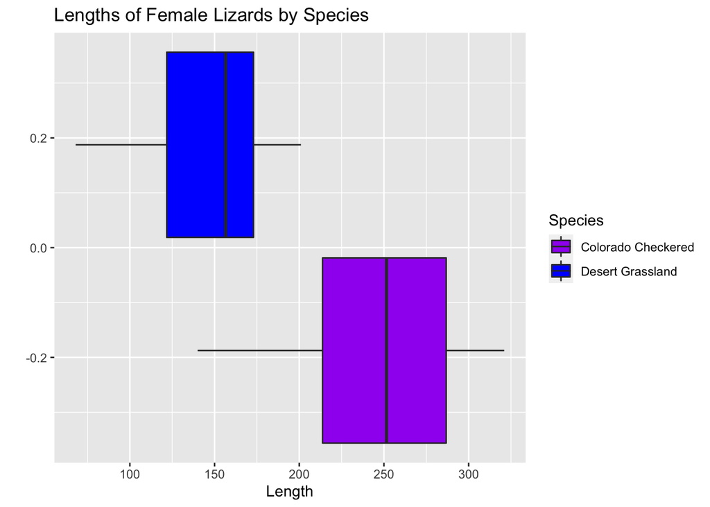

```r
# Assinging graph values
ggplot(data = lizards_sex_species, aes(x = total_length, fill = spp)) +
  geom_boxplot(bins = 40) +
#Assigning names for key
  scale_fill_manual(values = c("purple", "blue"), name = "Species") +
  labs(x = "Length", y = "", title = "Lengths of Female Lizards by Species" )
```

F.1 This graph compares the lengths of female lizards in millimeters by species (Colorado Checkered Lizard and Desert Grassland Lizard).

```r
# Get mean, sd and sample size of female lizard lengths
lizard_stats <- lizards_sex_species %>%
  group_by(spp) %>%
  summarize(mean_length = round(mean(total_length, na.rm = TRUE),2),
            sd_length = round(sd(total_length, na.rm = TRUE),2),
            sample_size = n())
# Create a table
lizard_stats %>%
# Add titles and labels
  kable(caption = "Table 1. Statistics for Female Lizard Species", col.names = c("Species",
                      "Mean Diameter (mm)",
                      "Standard Deviation",
                      "Sample Size (n)")) %>%
  kable_styling(full_width = TRUE)
```

Table 1. Statistics for Female Lizard Species

| Species | Mean Diameter (mm) | Standard Deviation | Sample Size (n) |
| --- | --- | --- | --- |
| Colorado Checkered | 244.89 | 47.32 | 28 |
| Desert Grassland | 147.60 | 34.55 | 47 |

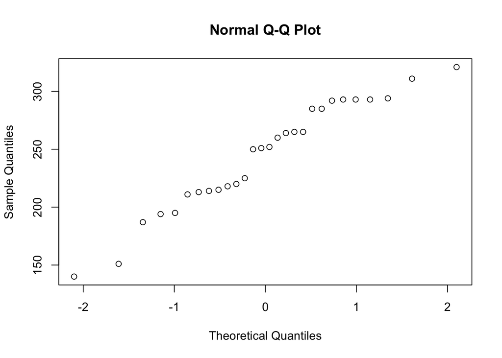

```r
# Calculate means of Colorado Lizards and Desert Lizards
species_colorado <- lizards_sex_species %>%
  filter(spp == "Colorado Checkered") %>%
  drop_na(total_length) %>%
  pull(total_length)

species_desert <- lizards_sex_species %>%
  filter(spp == "Desert Grassland") %>%
  drop_na(total_length) %>%
  pull(total_length)

qqnorm(species_colorado)
```